# Intro Page

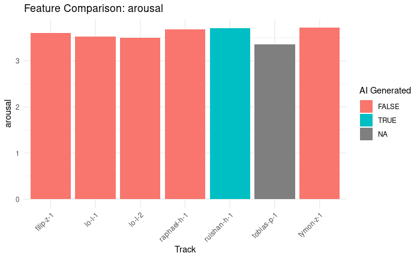

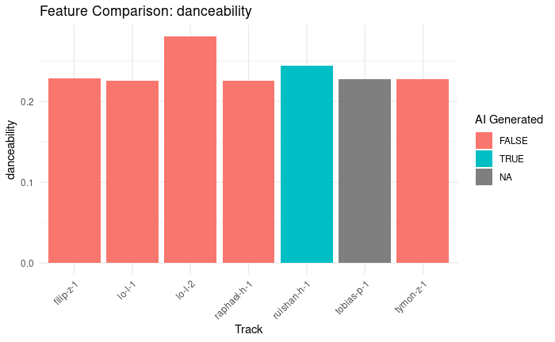

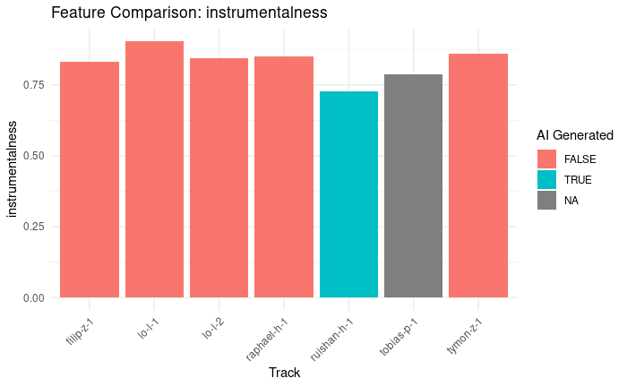

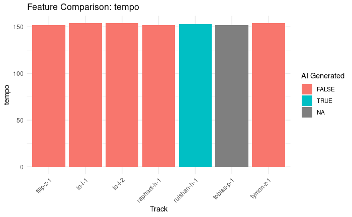

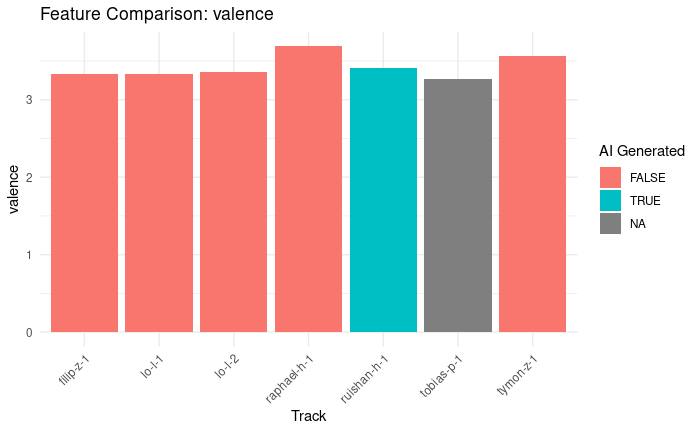

For my two pieces of music, the Chinese and Japanese music generated by the AI has very strong similarities with some Western music in terms of arousal and valence, which confirms my findings in track-level features, i.e., the AI’s understanding of valence and arousal is more based on the conventions of Western music, so the AI-generated music does not meet my specific requirements for low valance with high arousal in Asian battlefield drumming.

# Random Forests

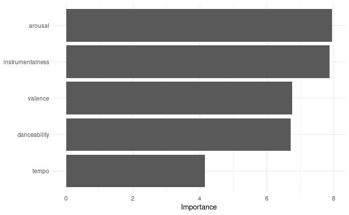

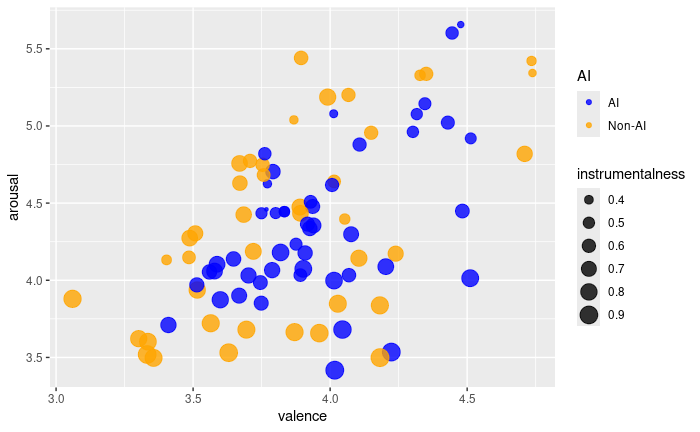

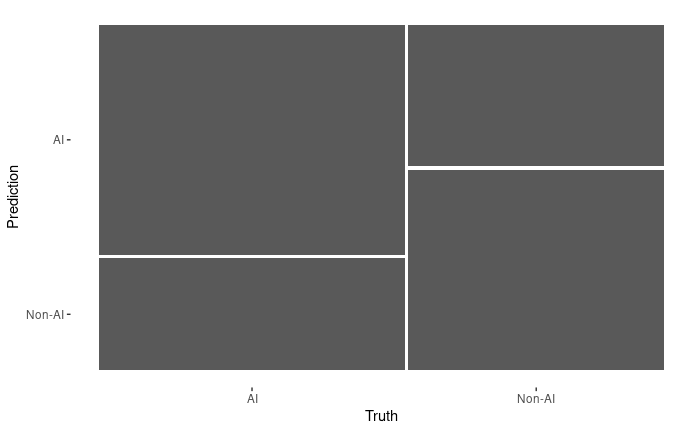

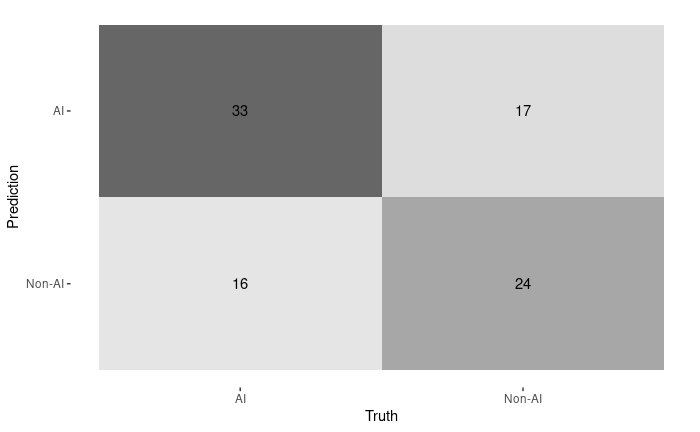

While the clustering model on the previous page is convenient, it is worth noting that this model does not differentiate AI-generated music from non-AI-generated music when classifying, for example, the AI-generated Chinese music ruishan-h-1 is classified with six non-AI-generated music. So what features can help classification models in machine learning to distinguish AI-generated music from non-AI-generated music? Random Forests can help to calculate and visualize which features are most helpful in distinguishing AI from non-AI. In this figure, it can be seen that arousal, instrumentalness, and valence are most helpful in recognizing whether music is AI-generated or not. And the relationship between these three features and AI and non-AI generated music can be seen in the next plot. It can be seen that lower valence is associated with lower arousal is the main feature of AI-generated music, which is consistent with the relationship between valence and arousal in my two AI-generated music. The relationship between valence and arousal in non-AI-generated music, on the other hand, is more flexible than in AI-generated music. This means that if I want to fulfill my prompts for Asian music, I’d be better off creating the music myself or hiring someone to do it rather than relying on an AI. Unfortunately, I have no musical training nor do I have enough money to hire a talented musicians.

# Conclusion and Contribution

At the end of the portfolio, I should put aside for a moment my strong disappointment with AI-generated music and return to my research question.

Specifically, the user needs to determine which track-level features the AI-generated music needs to have based on the specific cultural context of the music. And whether there are specific pitch, timbre, and rhythmic requirements. AI-generated music is often audio-only, and neither the score nor the instruments used to generate the music are provided. Therefore there is no direct access to pitch, tempo and timbre information. However, pitch and the chords used in the music can be observed through Chromagrams and Chordograms, timbre can be observed through Cepstrograms, Chroma-based self-similarity, Timbre-based self-similarity, and the music’s rhythm can be observed through Novelty Functions, and Tempograms. In this way, AI-generated music is no longer a mystery, and one can test whether the generated music meets the requirements.

The traditional Chinese and Japanese drums that I asked the AI to generate did not match my input prompts.This may be due to the AI’s unfamiliarity with traditional Asian music culture since the unique musical features, pitch, timbre, and rhythm of Asian drum music are closely related to the cultural conventions behind the music.

I hope that future researchers and musicians will not only let AI expose to Western music while ignoring Asian music when training AI music composition models. Also don’t only expose AI to modern music and ignore traditional music. Both Eastern and Western music are wonderful, and both traditional and modern music are enjoyable, and not allowing the AI to have a well-rounded experience is not only a little bit pity, but also affects the quality of the music the AI outputs.

Limitations

As a student studying linguistics, I am familiar with corpora, but when dealing with the class corpus, I feel powerless instead of confident. The reason is that in linguistics, it is very common to combine quantitative and qualitative research, such as combining a corpus with interviews to get objective data and have direct contact with the data providers who can share ask their subjective feelings and opinions.

However, I did not take the initiative to interview my classmates when I processed the class corpus, so I do not know whether they liked the music they generated with the AI, whether they generated Western or Asian music, or which instruments they used, and which musical styles they used. I listened carefully to every piece of audio in the class corpus, but even distinguishing between the sounds of a flute and a violin was very difficult for me since I never have any musical training.

Not having interviews to have access to the creators of the music is the biggest regret of my portfolio. If I could have had the opportunity to interview them, I would have been able to organize clear tables about the style of the music, the use of instruments, whether it was oriental or not, etc., instead of relying on my subjective guesses as I do now. I hope that future researchers can try to combine corpus research and interviews, and listen more to the feelings and opinions of the music creators instead of just relying on objective data.